# HW2_Q2_2018

'HW2_qatar_tsp' contains latitude and longitude data of 194 cities in a country in Qatar. To plot the data we use 'basemap' from 'pl_toolkits' in this question. This library is available from Matplotlib.

'basemap' is not installed by default and you might need to install it yourself.

Before the start of writing any codes, it is important to load the appropriate libraries at the top.

```python
# Import networkx library and rename it as nx.
import networkx as nx

from math import *
import random

# Adding support for high-performance, easy-to-use data structures and data analysis tools
import pandas as pd

# Adding support for large, multi-dimensional arrays and matrices.
import numpy as np
from gurobipy import *

# Import matplotlib libraries
import matplotlib.pyplot as plt

import os
from mpl_toolkits.basemap import Basemap
```

We first load the contents from the files and calculate the distance. For easier file importing we remove the file header and put the line "node latitude longitude" to distinguish different variables.

```python
data = pd.read_csv('HW2_qatar_tsp.txt', sep = " ")

points = {}
# Scaled the data by 1000
points['latitude'] = data['latitude'] / 1000
points['longitude'] = data['longitude'] / 1000


# Also store the longitudes and latitudes in two arrays
lons = np.array(data['longitude'] / 1000)
lats = np.array(data['latitude'] / 1000)
```

### Calculate the distance matrix using approximation

```python
"""
For a pair of places, calculate the distance between them based on spherical coordinates.

Args:
    points = pandas dataframe containing all points,
    i = index of the first city,
    j = index of the second city

Returns:
    The distance between two points on the Earth
"""

def distance(points, i, j):
    lat1 = points['latitude'][i]
    lat2 = points['latitude'][j]
    long1 = points['longitude'][i]
    long2 = points['longitude'][j]

    # Convert latitude and longitude to
    # spherical coordinates in radians.
    degrees_to_radians = pi / 180.0

    # phi = 90 - latitude
    phi1 = (90.0 - lat1)*degrees_to_radians
    phi2 = (90.0 - lat2)*degrees_to_radians

    # theta = longitude
    theta1 = long1 * degrees_to_radians
    theta2 = long2 * degrees_to_radians

    # Compute spherical distance from spherical coordinates.
    #
    # For two locations in spherical coordinates
    # (1, theta, phi) and (1, theta', phi')
    # cosine( arc length ) =
    # sin phi sin phi' cos(theta-theta') + cos phi cos phi'
    # distance = rho * arc length

    cos1 = (sin(phi1)*sin(phi2)*cos(theta1 - theta2) + cos(phi1)*cos(phi2))
    cos1 = round(cos1,8)

    # Remember to multiply arc by the radius of the earth
    # in your favorite set of units to get the length.
    arc = acos( cos1 ) * 6373

    return arc
```

Then, the distance matrix is calculated and stored in distance_mat object.

```python
# Define n as a number of points
n = len(points['latitude'])

distance_mat = np.zeros((n, n))
for i in range(n):
    for j in range(n):
        distance_mat[i, j] = distance(points, i, j)

print(distance_mat)
```

```
[[  0.          37.58454843  56.70198251 ... 158.63163693 160.83131394
  158.24451305]
 [ 37.58454843   0.          19.95065386 ... 152.87863906 153.13349347
  155.11536968]
 [ 56.70198251  19.95065386   0.         ... 146.37425456 145.58960484
  149.95190155]
 ...
 [158.63163693 152.87863906 146.37425456 ...   0.           8.30937597
   11.0015051 ]
 [160.83131394 153.13349347 145.58960484 ...   8.30937597   0.
   19.26713683]
 [158.24451305 155.11536968 149.95190155 ...  11.0015051   19.26713683
    0.        ]]
```

### a. Plot the latitude and longitude as a scatter plot using a drawing package

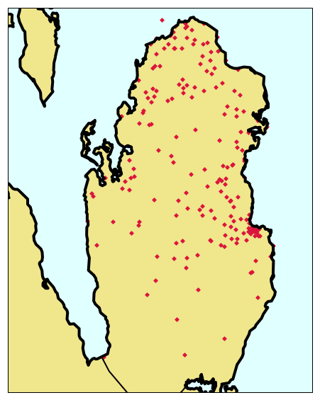

```python
plt.figure(figsize = (10,10))

# Plot the area around Djibouti

# lon_0, lat_0 is central point
# llcrnrlon is the longitude of lower left hand corner of the desired map domain (degrees).
#
# For the complete info, please refer to https://matplotlib.org/basemap/api/basemap_api.html
map = Basemap(projection='merc', lat_0 = np.mean(lats), lon_0 = np.mean(lons),
      resolution = 'h', area_thresh = 10,
      llcrnrlon = 50.4, llcrnrlat = 24.6,
      urcrnrlon = 51.8, urcrnrlat = 26.2)


# Plot all the latitudes and longitudes as a scatter plot
x, y = map(lons, lats)
map.scatter(x, y, s = 15, marker = 'D',color = 'crimson')

# Draw the map, setting the line width for the coast and the countries, fill the color
map.drawcoastlines(linewidth = 4)
map.drawcountries(linewidth = 2)
map.fillcontinents(color = 'khaki',lake_color = 'lightcyan', zorder = 0)
map.drawmapboundary(fill_color = 'lightcyan')


plt.show()
```

### b. Use the or-tools traveling salesman routine to find a tour of the 194 cities

```python
# Import Google OR-Tools
from ortools.constraint_solver import pywrapcp

"""
For a pair of places, whose indices in the adjacency matrix are from_node and to_node,
the callback accepts the two indices and returns the corresponding entry of the adjacency matrix.

Args:
    adj_matrix: The adjacency matrix

Returns:
    The callback function that calculates the distance.
"""

def create_distance_callback(adj_matrix):

    # Create a callback to calculate distances between cities.
    def distance_callback(from_node, to_node):
        #print(from_node, to_node)
        return int(adj_matrix[from_node][to_node])

    return distance_callback

# Hard code the node name
node_name = []
for i in range(n):
    node_name.append(i)

num_routes = 1
depot = 0
tsp_size = n

# Create routing model
if tsp_size > 0:
    # The solver instance is declared by:
    # The parameters are: tsp_size - The number of cities,
    #                     num_routes — The number of routes,
    #                     depot — The start and end node of the route
    routing = pywrapcp.RoutingModel(tsp_size, num_routes, depot)
    search_parameters = pywrapcp.RoutingModel.DefaultSearchParameters()

    # Create the distance callback.
    dist_callback = create_distance_callback(distance_mat)
    routing.SetArcCostEvaluatorOfAllVehicles(dist_callback)
```

After initalization, we can invoke the solver and display the results.

```python
# Solve the problem.
assignment = routing.SolveWithParameters(search_parameters)

route_str = ""

# if there is an solution
if assignment:
    print("Total distance: " + str(assignment.ObjectiveValue()))
    # Display the solution.
    # Only one route here; otherwise iterate from 0 to routing.vehicles() - 1
    route_number = 0
    # Index of the variable for the starting node.
    index = routing.Start(route_number)
    route = ''
    # print out the route
    while not routing.IsEnd(index):
        # Convert variable indices to node indices in the displayed route.
        route += str(node_name[routing.IndexToNode(index)]) + ' -> '
        index = assignment.Value(routing.NextVar(index))
        route += str(node_name[routing.IndexToNode(index)]) + ' '
        route_str = "Route:" + " "  + route
        #print("Route:" + " "  + route)
else:
    print('No solution found.')

print(route_str)
```

```
Total distance: 958
Route: 0 -> 5 5 -> 7 7 -> 15 15 -> 12 12 -> 22 22 -> 24 24 -> 16 16 -> 13 13 -> 10 10 -> 6 6 -> 3 3 -> 1 1 -> 2 2 -> 4 4 -> 8 8 -> 9 9 -> 11 11 -> 14 14 -> 18 18 -> 29 29 -> 31 31 -> 34 34 -> 30 30 -> 26 26 -> 21 21 -> 17 17 -> 20 20 -> 25 25 -> 23 23 -> 32 32 -> 27 27 -> 28 28 -> 36 36 -> 38 38 -> …
```

### c. Challenge problem, finding an optimal tour using Gurobi (Solution from Group 2)

We connect with the Python interface of Gurobi and find an optimal tour using the sub-tour elimination integer programming formulation.

```python
"""
    Add the sub-tour elimination constraints. This function calls 'subtour' to
    verify the optimal tour we found in previous solutions, if previous solution
    has subtour, add another subtour elimination constraint and repeat solving
    process until a an optimal tour without subtours is found

"""

def subtourelim(model, where):

    if where == GRB.callback.MIPSOL:
        selected = []
        # make a list of edges selected in the solution
        for i in range(n):
            sol = model.cbGetSolution([model._vars[i,j] for j in range(n)])
            selected += [(i,j) for j in range(n) if sol[j] > 0.5]

        # find the shortest cycle in the selected edge list
        tour = subtour(selected)
        if len(tour) < n:
            # add a subtour elimination constraint
            expr = 0
            for i in range(len(tour)):
                for j in range(i+1, len(tour)):
                    expr += model._vars[tour[i], tour[j]]
            model.cbLazy(expr <= len(tour)-1)

'''
    Given a list of edges, find the shortest tour, if the length of shortest tour is not equal to the number of nodes, there
    exists subtour and need add another constraint
'''

def subtour(edges):

    visited = [False]*n
    cycles = []
    lengths = []
    selected = [[] for i in range(n)]

    for x,y in edges:
        selected[x].append(y)
    while True:
        current = visited.index(False)
        thiscycle = [current]
        while True:
            visited[current] = True
            neighbors = [x for x in selected[current] if not visited[x]]
            if len(neighbors) == 0:
                break
            current = neighbors[0]
            thiscycle.append(current)
        cycles.append(thiscycle)
        lengths.append(len(thiscycle))
        if sum(lengths) == n:
            break

    return cycles[lengths.index(min(lengths))]
```

However, we cannot generate all the sub-tour elimination constraints at once, we will start with a problem with only the degree = 2 constraints

```python
# Create the model
m = Model("tsp")


vars = {}
for i in range(n):
    for j in range(i+1):
        vars[i,j] = m.addVar(vtype = GRB.BINARY, name = 'edge' + str(i) + '_' + str(j))
        vars[j,i] = vars[i,j]

m.update()
```

```
Academic license - for non-commercial use only
```

Next, the objective function to minimize the total tour distance is added to the model.

```python
objValue = quicksum(vars[i, j] * distance(points, i, j)
                    for i in range(n)
                    for j in range(i+1))

m.setObjective(objValue, GRB.MINIMIZE)
m.update()
```

Then, the problem is started with only the degree = 2 constraints.

```python
# Add degree-2 constraint, and forbid loops
for i in range(n):
    m.addConstr(quicksum(vars[i,j] for j in range(n)) == 2)

    # no route to myself
    vars[i,i].ub = 0

m.update()
m._vars = vars
```

With all of these components, here is the attempt to optimize the model.

```python
m.params.LazyConstraints = 1
# add subtour elimination constraint gradually until find the optimal tour without subtour
m.optimize(subtourelim)

solution = m.getAttr('x',vars)
selected = [(i,j) for i in range(n) for j in range(n) if solution[i,j] > 0.5]
tour = subtour(selected)

assert len(subtour(selected)) == n

print('')
print('Optimal tour: %s' % str(tour))
print('Optimal cost: %g' % m.objVal)
print('')


m.optimize()
objectiveValue = m.ObjVal

solution = m.getAttr('x', vars)
# Pick the solution if that is close to 1
selected_edges = [(i,j) for i in range(n) for j in range(n) if solution[i,j] > 0.9]

print(selected_edges)
```

```
Changed value of parameter LazyConstraints to 1
   Prev: 0  Min: 0  Max: 1  Default: 0
Optimize a model with 194 rows, 18915 columns and 37636 nonzeros
Variable types: 0 continuous, 18915 integer (18915 binary)
Coefficient statistics:
  Matrix range     [1e+00, 1e+00]
  Objective range  [9e-01, 2e+02]
  Bounds range     [1e+00, 1e+00]
  RHS range        [2e+00, 2e+00]
Presolve removed 0 rows and 194 columns
Presolve time: 0.04s
Presolved: 194 rows, 18721 columns, 37442 nonzeros
Variable types: 0 continuous, 18721 integer (18721 binary)

Root relaxation: objective 9.440096e+02, 304 iterations, 0.01 seconds

    Nodes    |    Current Node    |     Objective Bounds      |     Work
 Expl Unexpl |  Obj  Depth IntInf | Incumbent    BestBd   Gap | It/Node Time

     0     0  944.00957    0   40          -  944.00957      -     -    0s
     0     0  953.44158    0   30          -  953.44158      -     -    0s
     0     0  955.53873    0   29          -  955.53873      -     -    0s
     0     0  956.81767    0   30          -  956.81767      -     -    0s
     0     0  956.89904    0   36          -  956.89904      -     -    0s
     0     0  956.91228    0   30          -  956.91228      -     -    0s
     0     0  956.91228    0   30          -  956.91228      -     -    0s
     0     2  956.91228    0   30          -  956.91228      -     -    1s
   668   650 1063.97669  288   15          -  959.55936      -   2.9    5s
  1230  1155  983.70138   42    6          -  976.82683      -   3.5   10s
* 1614  1308             147    1035.4034620  976.82683  5.66%   4.1   12s
  1913  1491  994.49055   73   20 1035.40346  977.24456  5.62%   4.5   15s
H 3000  1234                    1008.7584891  977.38135  3.11%   4.9   19s
  3135  1288  996.58422   40    8 1008.75849  977.40725  3.11%   5.0   20s
* 3136   877              42     997.8944564  977.40725  2.05%   5.0   20s
* 3137   791              41     996.9053020  977.40725  1.96%   5.0   20s
* 3550   834              68     996.3465799  978.00713  1.84%   5.0   21s
* 3863   839              62     992.7841702  978.43289  1.45%   5.1   22s
* 3865   804              60     992.4182672  978.43289  1.41%   5.1   22s
* 4331   870              40     991.5871872  979.56741  1.21%   5.3   23s
H 4333   657                     989.4710643  979.56741  1.00%   5.3   23s
```

[output cut: 36 more lines]

```
Cutting planes:
  Gomory: 13
  Flow cover: 2
  Inf proof: 6
  Zero half: 23
  Lazy constraints: 99

Explored 6440 nodes (43000 simplex iterations) in 0.04 seconds
Thread count was 4 (of 4 available processors)

Solution count 10: 987.791 987.847 988.874 ... 997.894

Optimal solution found (tolerance 1.00e-04)
Best objective 9.877907744887e+02, best bound 9.877150841043e+02, gap 0.0077%
[(0, 3), (0, 5), (1, 2), (1, 3), (2, 1), (2, 4), (3, 0), (3, 1), (4, 2), (4, 8), (5, 0), (5, 7), (6, 10), (6, 16), (7, 5), (7, 15), (8, 4), (8, 9), (9, 8), (9, 11), (10, 6), (10, 13), (11, 9), (11, 14), (12, 15), (12, 22), (13, 10), (13, 24), (14, 11), (14, 18), (15, 7), (15, 12), (16, 6), (16, 25),…
```

### d. Plot the resulting tour on the scatter plot

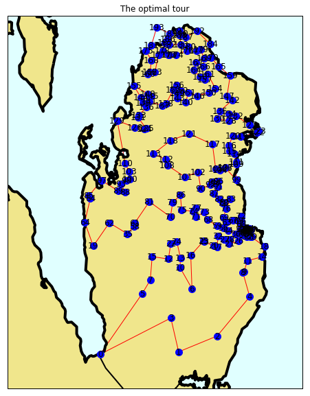

```python
plt.figure(figsize = (10,10))

# Plot the area around Djibouti again
map = Basemap(projection='merc', lat_0 = np.mean(lats), lon_0 = np.mean(lons),
    resolution = 'h', area_thresh = 10,
    llcrnrlon = 50.4, llcrnrlat = 24.6,
    urcrnrlon = 51.8, urcrnrlat = 26.2)

map.drawcoastlines(linewidth = 4)
map.drawcountries(linewidth = 2)
map.fillcontinents(color = 'khaki',lake_color = 'lightcyan', zorder = 0)
map.drawmapboundary(fill_color = 'lightcyan')

#
# Using NetworkX to put map projection coordinates in pos dictionary
G = nx.Graph()
G.add_edges_from(selected_edges)
pos = {}
for i in range(0,n):
    pos[i] = (x[i], y[i])

# draw the graph over the map
nx.draw_networkx(G, pos, node_size = 100, node_color = 'blue', edge_color = 'red')

plt.title('The optimal tour')
plt.show()
```